# Phylogenetic imputation of missing bird morphology: a pigauto demonstration

## 3 Preprocessing

```r
traits <- avonet300[, -1]
rownames(traits) <- avonet300$Species_Key

pd <- preprocess_traits(traits, tree300, log_transform = TRUE)
print(pd)
```

```
#> pigauto_data
#>   Species: 300
#>   Traits: 4 : Mass, Beak.Length_Culmen, Tarsus.Length, Wing.Length
#>   Log-transformed: TRUE
```

After log-transformation and z-scoring, all traits have mean ≈ 0 and SD ≈ 1.

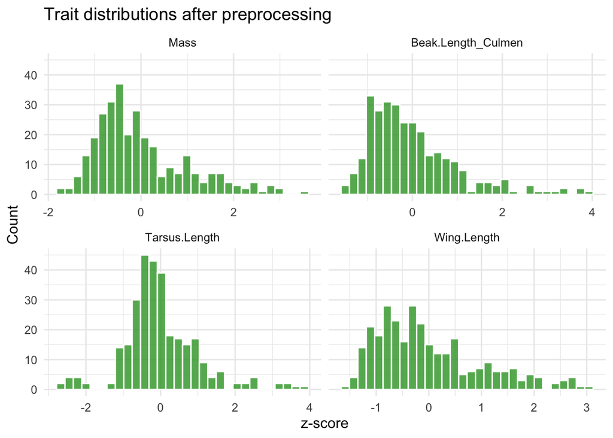

Trait distributions after log-transformation and z-scoring.

```r
df_scaled <- as.data.frame(pd$X_scaled)
df_scaled_long <- stack(df_scaled)
names(df_scaled_long) <- c("z", "trait")

ggplot(df_scaled_long, aes(x = z)) +
  geom_histogram(bins = 30, fill = "#33a02c", colour = "white", alpha = 0.8) +
  facet_wrap(~ trait, scales = "free_x") +
  theme_minimal(base_size = 12) +
  labs(x = "z-score", y = "Count",
       title = "Trait distributions after preprocessing")
```

## 4 Experimental design

We simulate missingness by randomly designating 25% of all matrix cells (300 species × 4 traits = 1200 cells) as “missing”. These held-out cells are never seen by the model during training and provide an honest out-of-sample test.

The missing cells are split into:

- **Validation (25% of missing)**: used for early stopping.
- **Test (75% of missing)**: used for final evaluation only.

```r
splits <- make_missing_splits(pd$X_scaled, missing_frac = 0.25, seed = 42)

cat("Held-out cells:\n")
```

```
#> Held-out cells:
```

```r
cat("  Validation:", length(splits$val_idx), "\n")
```

```
#>   Validation: 75
```

```r
cat("  Test:      ", length(splits$test_idx), "\n")
```

```
#>   Test:       225
```

```r
cat("  Total:     ", length(splits$val_idx) + length(splits$test_idx), "\n")
```

```
#>   Total:      300
```

```r
cat("  (Expected 25% of 1200 =", 0.25 * 1200, ")\n")
```

```
#>   (Expected 25% of 1200 = 300 )
```